# Practical Machine Learning Project

Komal

September 30, 2016

### Load packages

```r
library(AppliedPredictiveModeling)
library(caret)
library(e1071)
library(data.table)
library(readr)
```

## Project Introduction

**Background**  
Personal activity data can now be collected using devices such as Jawbone Up, Nike FuelBand, and Fitbit on a large amount inexpensively. These type of devices are part of the quantified self movement - a group of enthusiasts who take measurements about themselves regularly to improve their health, to find patterns in their behavior, or because they are tech geeks. One thing that people regularly do is quantify how much of a particular activity they do, but they rarely quantify how well they do it. In this project, your goal will be to use data from accelerometers on the belt, forearm, arm, and dumbell of 6 participants. They were asked to perform barbell lifts correctly and incorrectly in 5 different ways. More information is available from the website here: http://groupware.les.inf.puc-rio.br/har (see the section on the Weight Lifting Exercise Dataset).

**Data**  
The training data for this project are available here: https://d396qusza40orc.cloudfront.net/predmachlearn/pml-training.csv The test data are available here: https://d396qusza40orc.cloudfront.net/predmachlearn/pml-testing.csv The data for this project come from this source: http://groupware.les.inf.puc-rio.br/har. If you use the document you create for this class for any purpose please cite them as they have been very generous in allowing their data to be used for this kind of assignment.

**Goal**  
The goal of your project is to predict the manner in which they did the exercise. This is the “classe” variable in the training set. You may use any of the other variables to predict with. You should create a report describing how you built your model, how you used cross validation, what you think the expected out of sample error is, and why you made the choices you did. You will also use your prediction model to predict 20 different test cases.

## Gettind and Loading the Data

```r
training <- read.csv("D:/BI/Coursera/Courses/10PracticalMachineLearning/pml-training.csv")
testing <- read.csv("D:/BI/Coursera/Courses/10PracticalMachineLearning/pml-testing.csv")
dim(training)
```

```
## [1] 19622   160
```

```r
dim(testing)
```

```
## [1]  20 160
```

```r
head(training$classe)
```

```
## [1] A A A A A A
## Levels: A B C D E
```

```r
prop.table(table(training$classe))*100
```

```
##
##        A        B        C        D        E
## 28.43747 19.35073 17.43961 16.38977 18.38243
```

```r
str(training)
```

```
## 'data.frame':    19622 obs. of  160 variables:
##  $ X                       : int  1 2 3 4 5 6 7 8 9 10 ...
##  $ user_name               : Factor w/ 6 levels "adelmo","carlitos",..: 2 2 2 2 2 2 2 2 2 2 ...
##  $ raw_timestamp_part_1    : int  1323084231 1323084231 1323084231 1323084232 1323084232 1323084232 1323084232 1323084232 1323084232 1323084232 ...
##  $ raw_timestamp_part_2    : int  788290 808298 820366 120339 196328 304277 368296 440390 484323 484434 ...
##  $ cvtd_timestamp          : Factor w/ 20 levels "02/12/2011 13:32",..: 9 9 9 9 9 9 9 9 9 9 ...
##  $ new_window              : Factor w/ 2 levels "no","yes": 1 1 1 1 1 1 1 1 1 1 ...
##  $ num_window              : int  11 11 11 12 12 12 12 12 12 12 ...
##  $ roll_belt               : num  1.41 1.41 1.42 1.48 1.48 1.45 1.42 1.42 1.43 1.45 ...
##  $ pitch_belt              : num  8.07 8.07 8.07 8.05 8.07 8.06 8.09 8.13 8.16 8.17 ...
##  $ yaw_belt                : num  -94.4 -94.4 -94.4 -94.4 -94.4 -94.4 -94.4 -94.4 -94.4 -94.4 ...
##  $ total_accel_belt        : int  3 3 3 3 3 3 3 3 3 3 ...
##  $ kurtosis_roll_belt      : Factor w/ 397 levels "","-0.016850",..: 1 1 1 1 1 1 1 1 1 1 ...
##  $ kurtosis_picth_belt     : Factor w/ 317 levels "","-0.021887",..: 1 1 1 1 1 1 1 1 1 1 ...
##  $ kurtosis_yaw_belt       : Factor w/ 2 levels "","#DIV/0!": 1 1 1 1 1 1 1 1 1 1 ...
```

[output cut: 86 more lines]

## Cleaning Data

```r
# Set seed
set.seed(227)
```

Remove variables having high missing percentage (50%)

```r
training <- training[, colMeans(is.na(training)) <= .5]
dim(training)
```

```
## [1] 19622    93
```

Remove Zero and Near Zero-Variance Predictors

```r
nzv.result <- nearZeroVar(training)
training2 <- training[, -nzv.result]
dim(training2)
```

```
## [1] 19622    59
```

Identifying numeric variables

```r
numericData <- training2[sapply(training2, is.numeric)]
```

Calculate correlation matrix

```r
descrCor <- cor(numericData)
```

Check Correlation Plot

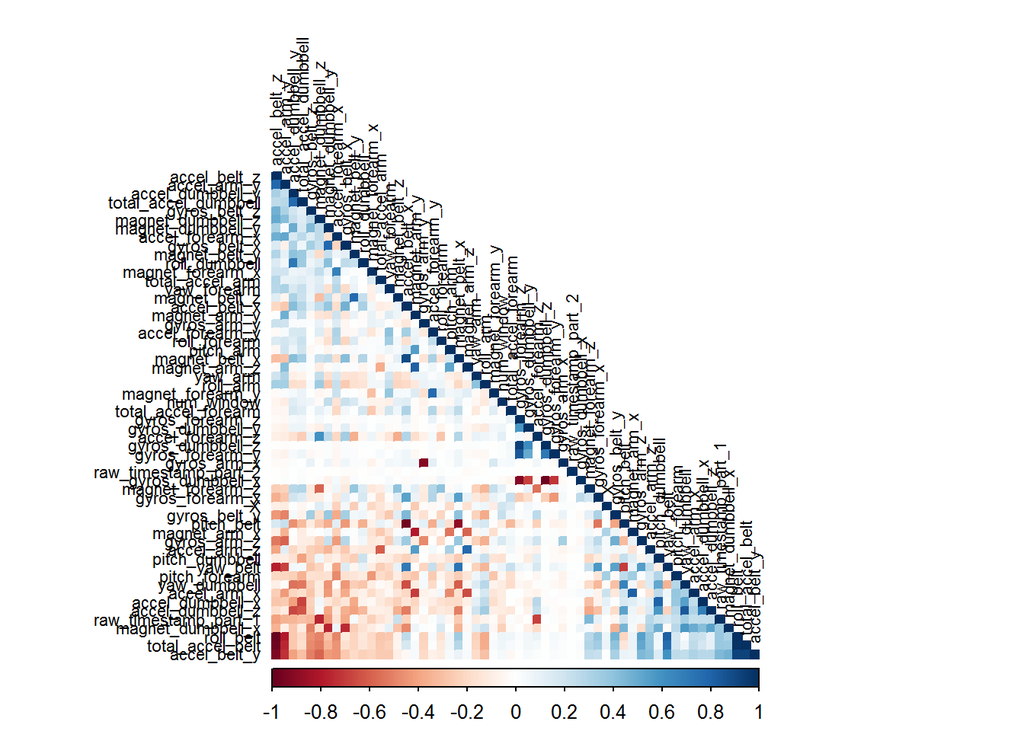

```r
library(corrplot)
corrplot(descrCor, order = "FPC", method = "color", type = "lower", tl.cex = 0.7, tl.col = rgb(0, 0, 0))
```

Find attributes that are highly corrected

```r
highlyCorrelated <- findCorrelation(descrCor, cutoff=0.7)
print(highlyCorrelated)
```

```
##  [1] 14  5 13 26  8  7 40 12 15 41 39 42 43 25 38 27 29 16 52 50 49 37 22
```

```r
highlyCorCol <- colnames(numericData)[highlyCorrelated]
highlyCorCol
```

```
##  [1] "accel_belt_z"      "roll_belt"         "accel_belt_y"
##  [4] "accel_arm_y"       "total_accel_belt"  "yaw_belt"
##  [7] "accel_dumbbell_z"  "accel_belt_x"      "magnet_belt_x"
## [10] "magnet_dumbbell_x" "accel_dumbbell_y"  "magnet_dumbbell_y"
## [13] "magnet_dumbbell_z" "accel_arm_x"       "accel_dumbbell_x"
## [16] "accel_arm_z"       "magnet_arm_y"      "magnet_belt_y"
## [19] "accel_forearm_y"   "gyros_forearm_z"   "gyros_forearm_y"
## [22] "gyros_dumbbell_z"  "gyros_arm_x"
```

Remove highly correlated variables and create a new dataset

```r
training3 <- training2[, -which(colnames(training2) %in% highlyCorCol)]
dim(training3)
```

```
## [1] 19622    36
```

## Model Building and Evaluation

```r
training4 <- training3[,c(-1,-36)]
names(training4)
```

```
##  [1] "user_name"            "raw_timestamp_part_1" "raw_timestamp_part_2"
##  [4] "cvtd_timestamp"       "num_window"           "pitch_belt"
##  [7] "gyros_belt_x"         "gyros_belt_y"         "gyros_belt_z"
## [10] "magnet_belt_z"        "roll_arm"             "pitch_arm"
## [13] "yaw_arm"              "total_accel_arm"      "gyros_arm_y"
## [16] "gyros_arm_z"          "magnet_arm_x"         "magnet_arm_z"
## [19] "roll_dumbbell"        "pitch_dumbbell"       "yaw_dumbbell"
## [22] "total_accel_dumbbell" "gyros_dumbbell_x"     "gyros_dumbbell_y"
## [25] "roll_forearm"         "pitch_forearm"        "yaw_forearm"
## [28] "total_accel_forearm"  "gyros_forearm_x"      "accel_forearm_x"
## [31] "accel_forearm_z"      "magnet_forearm_x"     "magnet_forearm_y"
## [34] "magnet_forearm_z"
```

```r
testing4 <- testing[,colnames(training4)]
names(testing4)
```

```
##  [1] "user_name"            "raw_timestamp_part_1" "raw_timestamp_part_2"
##  [4] "cvtd_timestamp"       "num_window"           "pitch_belt"
##  [7] "gyros_belt_x"         "gyros_belt_y"         "gyros_belt_z"
## [10] "magnet_belt_z"        "roll_arm"             "pitch_arm"
## [13] "yaw_arm"              "total_accel_arm"      "gyros_arm_y"
## [16] "gyros_arm_z"          "magnet_arm_x"         "magnet_arm_z"
## [19] "roll_dumbbell"        "pitch_dumbbell"       "yaw_dumbbell"
## [22] "total_accel_dumbbell" "gyros_dumbbell_x"     "gyros_dumbbell_y"
## [25] "roll_forearm"         "pitch_forearm"        "yaw_forearm"
## [28] "total_accel_forearm"  "gyros_forearm_x"      "accel_forearm_x"
## [31] "accel_forearm_z"      "magnet_forearm_x"     "magnet_forearm_y"
## [34] "magnet_forearm_z"
```

```r
names(training3)
```

```
##  [1] "X"                    "user_name"            "raw_timestamp_part_1"
##  [4] "raw_timestamp_part_2" "cvtd_timestamp"       "num_window"
##  [7] "pitch_belt"           "gyros_belt_x"         "gyros_belt_y"
## [10] "gyros_belt_z"         "magnet_belt_z"        "roll_arm"
## [13] "pitch_arm"            "yaw_arm"              "total_accel_arm"
## [16] "gyros_arm_y"          "gyros_arm_z"          "magnet_arm_x"
## [19] "magnet_arm_z"         "roll_dumbbell"        "pitch_dumbbell"
## [22] "yaw_dumbbell"         "total_accel_dumbbell" "gyros_dumbbell_x"
## [25] "gyros_dumbbell_y"     "roll_forearm"         "pitch_forearm"
## [28] "yaw_forearm"          "total_accel_forearm"  "gyros_forearm_x"
## [31] "accel_forearm_x"      "accel_forearm_z"      "magnet_forearm_x"
## [34] "magnet_forearm_y"     "magnet_forearm_z"     "classe"
```

```r
training3 <- training3[,-1]

## CROSS VALIDATION - RANDOM SAMPLING W/O REPLACEMENT
# split training set into sub-training/test sets
inTrain <- createDataPartition(y=training3$classe,p=0.60, list=FALSE)
sub_training <- training3[inTrain,]
sub_testing <- training3[-inTrain,]

#SVM
svm.result <- train(classe~., data = sub_training,method = "svmLinear")
predictions <- predict(svm.result, sub_testing)
confusionMatrix(sub_testing$classe,predictions)
```

```
## Confusion Matrix and Statistics
##
##           Reference
## Prediction    A    B    C    D    E
##          A 2093   92   47    0    0
##          B  231 1110  172    5    0
##          C   25  146 1141   55    1
##          D    0    9  155 1012  110
##          E    1    2    4  158 1277
##
## Overall Statistics
##
##                Accuracy : 0.8454
##                  95% CI : (0.8372, 0.8533)
##     No Information Rate : 0.2995
##     P-Value [Acc > NIR] : < 2.2e-16
##
##                   Kappa : 0.8041
##  Mcnemar's Test P-Value : NA
##
## Statistics by Class:
##
##                      Class: A Class: B Class: C Class: D Class: E
## Sensitivity            0.8906   0.8168   0.7512   0.8228   0.9200
## Specificity            0.9747   0.9371   0.9641   0.9586   0.9745
## Pos Pred Value         0.9377   0.7312   0.8341   0.7869   0.8856
## Neg Pred Value         0.9542   0.9607   0.9416   0.9668   0.9827
## Prevalence             0.2995   0.1732   0.1936   0.1568   0.1769
## Detection Rate         0.2668   0.1415   0.1454   0.1290   0.1628
## Detection Prevalence   0.2845   0.1935   0.1744   0.1639   0.1838
## Balanced Accuracy      0.9327   0.8769   0.8576   0.8907   0.9472
```

```r
# evaluate model on test data
predictions2 <- predict(svm.result,testing4)
predictions2
```

```
##  [1] A B C A A E D A A A B C B A E E A B A B
## Levels: A B C D E
```

```r
#CART
rf.result<-train(classe~., data = sub_training, method = "rpart")
predictions <- predict(rf.result, sub_testing)
confusionMatrix(sub_testing$classe,predictions)
```

```
## Confusion Matrix and Statistics
##
##           Reference
## Prediction    A    B    C    D    E
##          A 1742    7  268  162   53
##          B  308  514  231  441   24
##          C   33    0 1042  100  193
##          D   10    0  499  596  181
##          E   14    0  291  252  885
##
## Overall Statistics
##
##                Accuracy : 0.6091
##                  95% CI : (0.5982, 0.6199)
##     No Information Rate : 0.2971
##     P-Value [Acc > NIR] : < 2.2e-16
##
##                   Kappa : 0.5085
##  Mcnemar's Test P-Value : < 2.2e-16
##
## Statistics by Class:
##
##                      Class: A Class: B Class: C Class: D Class: E
## Sensitivity            0.8268  0.98656   0.4470  0.38427   0.6624
## Specificity            0.9146  0.86294   0.9409  0.89039   0.9144
## Pos Pred Value         0.7805  0.33860   0.7617  0.46345   0.6137
## Neg Pred Value         0.9350  0.99889   0.8010  0.85442   0.9296
## Prevalence             0.2685  0.06640   0.2971  0.19768   0.1703
## Detection Rate         0.2220  0.06551   0.1328  0.07596   0.1128
## Detection Prevalence   0.2845  0.19347   0.1744  0.16391   0.1838
## Balanced Accuracy      0.8707  0.92475   0.6940  0.63733   0.7884
```

```r
# evaluate model on test data
predictions2 <- predict(rf.result,testing4)
predictions2
```

```
##  [1] A C C A A D C D A A D C B A E E E D A B
## Levels: A B C D E
```

```r
#GBM
set.seed(12345)
fitControl <- trainControl(method = "repeatedcv",
                           number = 5,
                           repeats = 1)

gbmFit1 <- train(classe ~ ., data=sub_training, method = "gbm",
                 trControl = fitControl,
                 verbose = FALSE)
gbmFinMod1 <- gbmFit1$finalModel

gbmPredTest <- predict(gbmFit1, newdata=sub_testing)
gbmAccuracyTest <- confusionMatrix(sub_testing$classe,gbmPredTest)
gbmAccuracyTest
```

```
## Confusion Matrix and Statistics
##
##           Reference
## Prediction    A    B    C    D    E
##          A 2230    2    0    0    0
##          B    3 1508    3    4    0
##          C    0    2 1353   13    0
##          D    0    0    3 1282    1
##          E    0    0    0    1 1441
##
## Overall Statistics
##
##                Accuracy : 0.9959
##                  95% CI : (0.9942, 0.9972)
##     No Information Rate : 0.2846
##     P-Value [Acc > NIR] : < 2.2e-16
##
##                   Kappa : 0.9948
##  Mcnemar's Test P-Value : NA
##
## Statistics by Class:
##
##                      Class: A Class: B Class: C Class: D Class: E
## Sensitivity            0.9987   0.9974   0.9956   0.9862   0.9993
## Specificity            0.9996   0.9984   0.9977   0.9994   0.9998
## Pos Pred Value         0.9991   0.9934   0.9890   0.9969   0.9993
## Neg Pred Value         0.9995   0.9994   0.9991   0.9973   0.9998
## Prevalence             0.2846   0.1927   0.1732   0.1657   0.1838
## Detection Rate         0.2842   0.1922   0.1724   0.1634   0.1837
## Detection Prevalence   0.2845   0.1935   0.1744   0.1639   0.1838
## Balanced Accuracy      0.9992   0.9979   0.9966   0.9928   0.9996
```

```r
predictions2 <- predict(gbmFit1,testing4)
predictions2
```

```
##  [1] B A B A A E D B A A B C B A E E A B B B
## Levels: A B C D E
```